# WTP Model first pass

This is a first-pass attempt to model willingness to pay data. Let’s put the code together, WITHOUT testing the data, then consider pre-registration and then a test.

What are we pre-registering? Something like: - health and liking scores predict payment scores significantly better than either choice alone - hunger ratings moderate liking, so that an interaction term can be observed between liking and hunger when predicting bid, indicating that liking is more important for predicting the bid score when participants are hungrier. - hunger ratings also moderate the influence of health, so that an interaction can be observed between liking and hunger when predicting bids so that when participants are hungrier liking is less important

To model these data, we’ll use a multi-level model, where we predict individual bid based on health and liking score. At the participant level, we’ll model hunger.

Do we model any other participant factors? These might include:

- obesity level
- demographics (sex/gender, age, income)
- PSS

With only ~200 subjects, we’re probably under-specified to test *interactions* with more than a couple of participant-level variables.

Any other subject-level variables that might interact to predict greater predictivity of liking vs. health?

self control - impulsivity scale - self control scale - tempest self regulation scale for eating - restraint scale

food scarcity - childhood financial security - adult food security scale

reward sensitivity - Food Craving Inventory

Food habits - Food Frequency Inventory

Before testing each of these we may want to run some sort of correlation on them to look at the correlations between the scales. If items are uncorrelated, we could include them together in a single regression. If they are correlated, we might want to avoid testing them together, test their interaction, or pick one scale over another to analyze.

## original question

From our teams script the orignla question is

> We asked you to not eat for 3 hours prior to this appointment and to refrain from liquids for the past hour. Were you able to do that?

> And how hungry are you currently feeling on a scale from 1-5 where 1 = not hungry at all and 5 = extremely hungry?

> Record answer in Redcap

> Great! We would like you to continue fasting prior to the body composition assessment to obtain the most accurate results. After you complete the physical assessments, you’ll be able to drink fluids and after the MRI scan, we’ll provide you with a snack.

> We have a couple minutes before we need to get started. Would you like to visit the restroom or do you need anything before we get started?

> Do you have any questions for me before we start gathering some of the measurements?

## Implementation

### First: group-level predictors

In linear modeling terms what we are looking for is a *varying slope*; the varying slope will have a *group-level predictor* (e.g., hunger).

See Gelman & Hill, 12.6: group-level predictors; also 13.1.

### Next: interaction of group-level predictor

this is discussed in 13.1

What we have isn’t analogous to the simple radon problem, where we’res predicting indiviual-level (house) radon level from an individual-level predictor (floor=0 or 1) and a group-level (county) predictor. That would be analogous to predicting bid size based on hunger, food health, and food likeability separately. And I think, in a model, this would be using a group predictor to model the intercept of the individual level prediction.

Rather we want to get an interaction of the group-level predictor with the individual-level predictor. In the radon example, this would be like looking for an interaction between floor and county-level radon level.

In a multi-level model this isn’t too complicated, right–it’s just including the group-level item as a predictor of the group-level variable. This might be descrribed as predicting the slope $\beta_j$.

Gelman *still* doesn’t spell out the form for this in lme4 or lmer, though he does discuss it extensively. So. a quick google…

brief discussion here: https://biologyforfun.wordpress.com/2017/06/19/adding-group-level-predictors-in-glmm-using-lme4/ - not high quality and they specifically caution against using p-values ot test significance. Wonder if Gelman knows how to do it.

Gelman covers this in Section 17.2: varying intercepts and slopes with group-level predictors. He only offers Bugs code, though. We might use stan.

Can try: https://cran.r-project.org/web/packages/equatiomatic/vignettes/lme4-lmer.html

See also: https://github.com/lme4/lme4/issues/473

hmmm…so, individual-level predictors are food healthiness and tastiness. we might add RT but let’s keep it simple for now.

Let’s get some data.

```r
Sys.setenv(R_CONFIG_ACTIVE = Sys.info()["nodename"])
data_dir <- config::get("dev_analysis_data_dir")
#hunger data
setwd(paste0(paste0(data_dir,"hunger/")))
source("DEV-Session1Data_R_2022-08-29_2358.r")
redcap_data<-data
rm(data)
```

```r
wtp_raw <- read_csv(paste0(data_dir,"wtp_behavdesign_clean.csv"))
```

```r
library(dplyr)
table(redcap_data$hunger_1)
```

```
 1  2  3  4  5
44 87 84 54 14
```

```r
session_1_redcap_data <-redcap_data %>% filter(grepl("session_1", redcap_event_name))
hunger_data <- session_1_redcap_data %>% select(dev_id,hunger_1)


regress_data<-merge(roc_behavioral_data,hunger_data,by.x="subjectID",by.y="dev_id",all.x = TRUE,all.y=FALSE)
```

Now let’s adapt the columns to normed columns with hte names we used in the synthetic dtaset.

```r
#clean the rating column
#regress_data$rating_int<-as.integer(str_extract(regress_data$rating,"\\d*"))
#regress_data<-regress_data[1:1000,]
#regress_data[regress_data$response=="NULL","response"] <- NA
#regress_data$response<-as.numeric(regress_data$response)
#regress_data <- regress_data%>% group_by(subject,run,wave) %>% mutate(min_rating=min(rating_int,na.rm=TRUE),max_rating=max(rating_int,na.rm=TRUE)) %>% ungroup()
#regress_data$response_range <- regress_data$max_response - regress_data$min_response
#stopifnot(max(regress_data$response_range)==3)#max of the max range should be 3 exactly, the range from the max response minus the min response
#there are two groups of responses here grouped by run
#some use range 1,2,3,4; others use range 5,6,7,8
#we need to combine those for value.
#value_adjustment <- 0 - 4*(regress_data$min_response>4)
#regress_data$value_level <- regress_data$response + value_adjustment
#regress_data$value <- factor(regress_data$value_level,levels = c(1,2,3,4),labels="$0.00","$0.50","$1.00","$1.50")
#regress_data[regress_data$liking_rating==0,"liking_rating"]<-NA
```

```r
#must have tried for half an hour to et this to work within the loop and it didn't...
standardize<-function(x){return((x-mean(x,na.rm=TRUE))/sd(x,na.rm=TRUE))}

regress_data$rating_i<-as.integer(regress_data$rating)
```

```
NAs introduced by coercion
```

```r
regress_data$rating_norm<-standardize(regress_data$rating_i)

#regress_data$stimulus_f <- standardize(regress_data$liking_rating)

regress_data$hunger_norm <- standardize(regress_data$hunger_1)

regress_data$stimulus_f<-factor(regress_data$stimulus,levels=c("No Crave","Neutral","Crave"))

regress_data <- regress_data %>% group_by(subjectID,file,wave,run) %>%
  mutate(trial_n=1:n())
```

```r
library(lme4)
#compared to "No Crave", Neutral and Craved stimuli were rated much more highly.
#don't really undersatnd why thre is no substantial differnce between Neutral and Crave foods
model <- lme4::lmer(
  rating_norm ~ stimulus_f + (1 | subjectID),
  regress_data
  )
summary(model)
```

```
Linear mixed model fit by REML ['lmerMod']
Formula: rating_norm ~ stimulus_f + (1 | subjectID)
   Data: regress_data

REML criterion at convergence: 98149.9

Scaled residuals:
    Min      1Q  Median      3Q     Max
-2.4415 -0.6699 -0.1924  0.6626  3.1913

Random effects:
 Groups    Name        Variance Std.Dev.
 subjectID (Intercept) 0.07297  0.2701
 Residual              0.75369  0.8682
Number of obs: 38125, groups:  subjectID, 272

Fixed effects:
                  Estimate Std. Error t value
(Intercept)       -0.72479    0.01869  -38.78
stimulus_fNeutral  0.97114    0.01256   77.32
stimulus_fCrave    0.97151    0.01088   89.25

Correlation of Fixed Effects:
            (Intr) stml_N
stmls_fNtrl -0.336
stimls_fCrv -0.388  0.576
```

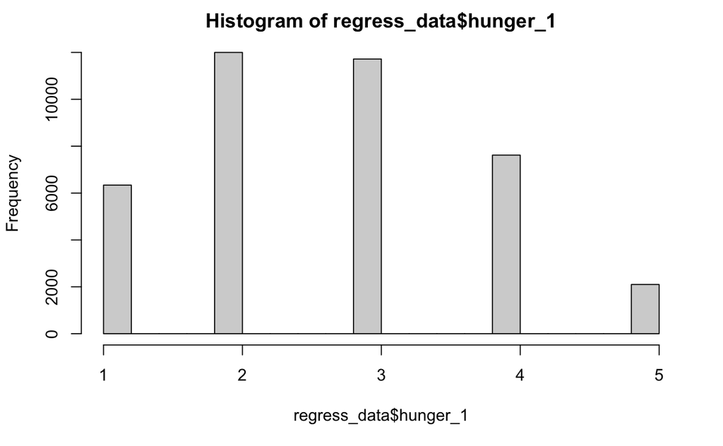

```r
hist(regress_data$hunger_1)
```

```r
# mean_by_food <- regress_data %>% #filter(health_cond=="unhealthy") %>%
#   group_by(food_pic) %>% summarise(
#   #hunger=mean(hunger_1,na.rm=TRUE),
#   liking_for_food = mean(liking_rating,na.rm=TRUE),
#   bid=mean(bid,na.rm=TRUE)
#   )
#
# cor.test(mean_by_food$liking_for_food,mean_by_food$bid)
#
#
#
# plot(mean_by_food$liking_for_food,mean_by_food$bid)
```

```r
# mean_by_subject <- regress_data %>% filter(health_cond=="unhealthy" & liking_rating==4) %>% group_by(subject) %>% summarise(
#   hunger=mean(hunger_1,na.rm=TRUE),
#   bid=mean(bid,na.rm=TRUE)
#   )
#
# cor.test(mean_by_subject$hunger,mean_by_subject$bid)
#
#
#
# plot(mean_by_subject$hunger,mean_by_subject$bid)
```

We don’t really care whether or not there are individual-level differences in the interaction between taste ratings and hunger norms. we just want to know, overall, whether they interact and whether modeling that interaction can make the model more predictive.

In fact, individual-level differences in interaction between taste ratings and hunger norms don’t make sense. there aren’t individual-level differences because there’s not an interaction ath the individual-level because there’s only one hunger norm per subject. So it’s nonsensical to include group-level variables in that bracket.

# Simple model

```r
model3a <- lme4::lmer(
  rating_norm ~ run + stimulus_f + hunger_norm + trial_n + (1 | subjectID),
  regress_data[!is.na(regress_data$hunger_norm),]
  )

summary(model3a)
```

```
Linear mixed model fit by REML ['lmerMod']
Formula: rating_norm ~ run + stimulus_f + hunger_norm + trial_n + (1 |      subjectID)
   Data: regress_data[!is.na(regress_data$hunger_norm), ]

REML criterion at convergence: 97047.7

Scaled residuals:
    Min      1Q  Median      3Q     Max
-2.5462 -0.6718 -0.1717  0.6707  3.1580

Random effects:
 Groups    Name        Variance Std.Dev.
 subjectID (Intercept) 0.07338  0.2709
 Residual              0.75007  0.8661
Number of obs: 37753, groups:  subjectID, 269

Fixed effects:
                    Estimate Std. Error t value
(Intercept)       -0.5938544  0.0221147 -26.853
runrun2           -0.0176808  0.0126276  -1.400
runrun3            0.0240926  0.0126478   1.905
runrun4           -0.0439183  0.0126689  -3.467
stimulus_fNeutral  0.9599869  0.0126298  76.010
stimulus_fCrave    0.9640923  0.0109216  88.274
hunger_norm        0.0179868  0.0171912   1.046
trial_n           -0.0108081  0.0007773 -13.904

Correlation of Fixed Effects:
            (Intr) runrn2 runrn3 runrn4 stml_N stml_C hngr_n
runrun2     -0.287
runrun3     -0.286  0.502
runrun4     -0.285  0.502  0.502
stmls_fNtrl -0.314 -0.001 -0.001 -0.001
stimls_fCrv -0.344 -0.002 -0.002 -0.003  0.577
hunger_norm  0.000  0.001  0.001  0.000 -0.001  0.000
trial_n     -0.393  0.004  0.003  0.004  0.078  0.043  0.000
```

Health ratings are the same for every subjectID, so it makes no sense to model the interaction of health_rating and hunger.

```r
model3b <- lme4::lmer(
  rating_norm ~ run + stimulus_f*hunger_norm + trial_n + (1 | subjectID),
  regress_data[!is.na(regress_data$hunger_norm),]
  )

summary(model3b)
```

```
Linear mixed model fit by REML ['lmerMod']
Formula: rating_norm ~ run + stimulus_f * hunger_norm + trial_n + (1 |      subjectID)
   Data: regress_data[!is.na(regress_data$hunger_norm), ]

REML criterion at convergence: 97050.7

Scaled residuals:
    Min      1Q  Median      3Q     Max
-2.5801 -0.6715 -0.1709  0.6708  3.1799

Random effects:
 Groups    Name        Variance Std.Dev.
 subjectID (Intercept) 0.07338  0.2709
 Residual              0.74988  0.8660
Number of obs: 37753, groups:  subjectID, 269

Fixed effects:
                                Estimate Std. Error t value
(Intercept)                   -0.5937835  0.0221133 -26.852
runrun2                       -0.0176743  0.0126260  -1.400
runrun3                        0.0240796  0.0126462   1.904
runrun4                       -0.0439123  0.0126673  -3.467
stimulus_fNeutral              0.9595662  0.0126288  75.982
stimulus_fCrave                0.9640206  0.0109205  88.276
hunger_norm                    0.0020660  0.0188432   0.110
trial_n                       -0.0108072  0.0007772 -13.905
stimulus_fNeutral:hunger_norm  0.0409165  0.0126040   3.246
stimulus_fCrave:hunger_norm    0.0113749  0.0109296   1.041

Correlation of Fixed Effects:
            (Intr) runrn2 runrn3 runrn4 stml_N stml_C hngr_n tril_n st_N:_
runrun2     -0.287
runrun3     -0.286  0.502
runrun4     -0.285  0.502  0.502
stmls_fNtrl -0.314 -0.001 -0.001 -0.001
stimls_fCrv -0.344 -0.002 -0.002 -0.003  0.577
hunger_norm -0.001  0.001  0.001  0.000  0.002  0.003
trial_n     -0.393  0.004  0.003  0.004  0.078  0.043  0.000
stmls_fNt:_  0.002  0.000  0.000  0.000 -0.010 -0.004 -0.334  0.000
stmls_fCr:_  0.003 -0.001  0.000 -0.001 -0.004 -0.007 -0.386  0.000  0.576
```

```r
anova(model3a,model3b)
```

```
refitting model(s) with ML (instead of REML)
```

```
Data: regress_data[!is.na(regress_data$hunger_norm), ]
Models:
model3a: rating_norm ~ run + stimulus_f + hunger_norm + trial_n + (1 | subjectID)
model3b: rating_norm ~ run + stimulus_f * hunger_norm + trial_n + (1 | subjectID)
        npar   AIC   BIC logLik deviance  Chisq Df Pr(>Chisq)
model3a   10 97007 97092 -48493    96987
model3b   12 96999 97102 -48488    96975 11.573  2   0.003069 **
---
Signif. codes:  0 ‘***’ 0.001 ‘**’ 0.01 ‘*’ 0.05 ‘.’ 0.1 ‘ ’ 1
```

# With stimulus random effects

If we didn’t include random effects of stimulus_f, then this would be significant.

However, it is possible that the effect of the stimulus likeability on ratings differs by subject.

In order to control for this we include it in the random effects of subject.

If we do that we will lose some power to detect interactions of stimulus and hunger.

However, if we don’t do this, we will risk labeling some of those individual subject effects on stimulus as effects of stimulus on rating.

Possibly this means it is time for some Bayesian mixed effects modeling…

```r
model3a <- lme4::lmer(
  rating_norm ~ run + stimulus_f + hunger_norm + trial_n + (1 + stimulus_f | subjectID),
  regress_data[!is.na(regress_data$hunger_norm),]
  )

summary(model3a)
```

```
Linear mixed model fit by REML ['lmerMod']
Formula: rating_norm ~ run + stimulus_f + hunger_norm + trial_n + (1 +      stimulus_f | subjectID)
   Data: regress_data[!is.na(regress_data$hunger_norm), ]

REML criterion at convergence: 91795.4

Scaled residuals:
    Min      1Q  Median      3Q     Max
-3.2248 -0.6724 -0.0821  0.6806  3.3448

Random effects:
 Groups    Name              Variance Std.Dev. Corr
 subjectID (Intercept)       0.1957   0.4424
           stimulus_fNeutral 0.4867   0.6976   -0.62
           stimulus_fCrave   0.2632   0.5130   -0.68  0.37
 Residual                    0.6281   0.7925
Number of obs: 37753, groups:  subjectID, 269

Fixed effects:
                    Estimate Std. Error t value
(Intercept)       -0.5907034  0.0302446 -19.531
runrun2           -0.0174628  0.0115581  -1.511
runrun3            0.0235923  0.0115770   2.038
runrun4           -0.0441204  0.0115961  -3.805
stimulus_fNeutral  0.9431262  0.0442628  21.307
stimulus_fCrave    0.9668979  0.0330125  29.289
hunger_norm        0.0176310  0.0171486   1.028
trial_n           -0.0107721  0.0007115 -15.141

Correlation of Fixed Effects:
            (Intr) runrn2 runrn3 runrn4 stml_N stml_C hngr_n
runrun2     -0.192
runrun3     -0.191  0.503
runrun4     -0.191  0.502  0.502
stmls_fNtrl -0.595  0.000  0.000  0.000
stimls_fCrv -0.652 -0.001 -0.001 -0.001  0.388
hunger_norm  0.000  0.001  0.001  0.000 -0.001  0.000
trial_n     -0.263  0.004  0.003  0.004  0.020  0.013  0.000
```

Health ratings are the same for every subjectID, so it makes no sense to model the interaction of health_rating and hunger.

```r
model3b <- lme4::lmer(
  rating_norm ~ run + stimulus_f*hunger_norm + trial_n + (1 + stimulus_f | subjectID),
  regress_data[!is.na(regress_data$hunger_norm),]
  )

summary(model3b)
```

```
Linear mixed model fit by REML ['lmerMod']
Formula: rating_norm ~ run + stimulus_f * hunger_norm + trial_n + (1 +      stimulus_f | subjectID)
   Data: regress_data[!is.na(regress_data$hunger_norm), ]

REML criterion at convergence: 91804.7

Scaled residuals:
    Min      1Q  Median      3Q     Max
-3.2250 -0.6726 -0.0819  0.6805  3.3457

Random effects:
 Groups    Name              Variance Std.Dev. Corr
 subjectID (Intercept)       0.1961   0.4428
           stimulus_fNeutral 0.4881   0.6987   -0.62
           stimulus_fCrave   0.2642   0.5140   -0.68  0.37
 Residual                    0.6281   0.7925
Number of obs: 37753, groups:  subjectID, 269

Fixed effects:
                                Estimate Std. Error t value
(Intercept)                   -0.5907142  0.0302710 -19.514
runrun2                       -0.0174634  0.0115581  -1.511
runrun3                        0.0235902  0.0115770   2.038
runrun4                       -0.0441216  0.0115961  -3.805
stimulus_fNeutral              0.9431219  0.0443229  21.278
stimulus_fCrave                0.9669155  0.0330702  29.238
hunger_norm                    0.0066909  0.0283747   0.236
trial_n                       -0.0107722  0.0007115 -15.141
stimulus_fNeutral:hunger_norm  0.0198137  0.0443605   0.447
stimulus_fCrave:hunger_norm    0.0122480  0.0331019   0.370

Correlation of Fixed Effects:
            (Intr) runrn2 runrn3 runrn4 stml_N stml_C hngr_n tril_n st_N:_
runrun2     -0.192
runrun3     -0.191  0.503
runrun4     -0.190  0.502  0.502
stmls_fNtrl -0.595  0.000  0.000  0.000
stimls_fCrv -0.653 -0.001 -0.001 -0.001  0.387
hunger_norm  0.001  0.001  0.001  0.000 -0.001 -0.001
trial_n     -0.263  0.004  0.003  0.004  0.020  0.013  0.000
stmls_fNt:_  0.000  0.000  0.000  0.000  0.000  0.000 -0.630  0.000
stmls_fCr:_  0.000  0.000  0.000  0.000  0.000  0.001 -0.694  0.000  0.387
```

```r
anova(model3a,model3b)
```

```
refitting model(s) with ML (instead of REML)
```

```
Data: regress_data[!is.na(regress_data$hunger_norm), ]
Models:
model3a: rating_norm ~ run + stimulus_f + hunger_norm + trial_n + (1 + stimulus_f | subjectID)
model3b: rating_norm ~ run + stimulus_f * hunger_norm + trial_n + (1 + stimulus_f | subjectID)
        npar   AIC   BIC logLik deviance  Chisq Df Pr(>Chisq)
model3a   15 91769 91897 -45869    91739
model3b   17 91772 91918 -45869    91738 0.2469  2     0.8839
```

We can demonstrate what the result would be if there really was a strong, subject-level interaction effect between `stimulus_f` and a subject-level variable with some synthetic data. We create a new fake variable, `psy_level`, the subject’s level of extrasensory perception (ESP). Then you create a fake interaction of that with the stimulus_f, which necessarily happens at the subject level, and model its causal effect on teh rating norm. Then, control for random effects of the stimulus, butn ot psy level, just as we did with hunger norm.

We see that unlike the hunger norm model, we don’t need to keep stimulus_f out of random effects in order to see a subject-level interaction effect of psyc_level and stimulus_f on the rating. We can also see psy level picking up fake precision (tho not fake point estimates) by omitting stimulus_f from the model.

Also seems to be the way they do it in Applied Multiple Regression/Correlation for the Behavioral Sciences (Cohen, Cohen, West, & Aiken), p551 14.7.2-3. ## Testing with fake dummy data

```r
subject_psy_level <- data.frame(
  "subjectID" =unique(regress_data$subjectID),
  "psy_level" = rnorm(n=unique(regress_data$subjectID))
)
regress_data_synth<-merge(regress_data,subject_psy_level)

#now let's say the subject's psy level interacts with stimulus_f to change ratings
#as well as having a main effect
regress_data_synth$rating_norm<-regress_data_synth$rating_norm+ regress_data_synth$psy_level*as.integer(regress_data_synth$stimulus_f)*0.1


model_fake0 <- lme4::lmer(
  rating_norm ~ run + stimulus_f + psy_level + trial_n + (1 + stimulus_f | subjectID),
  regress_data_synth[!is.na(regress_data_synth$hunger_norm),]
  )

summary(model_fake0)
```

```
Linear mixed model fit by REML ['lmerMod']
Formula: rating_norm ~ run + stimulus_f + psy_level + trial_n + (1 + stimulus_f |
    subjectID)
   Data: regress_data_synth[!is.na(regress_data_synth$hunger_norm), ]

REML criterion at convergence: 91825.1

Scaled residuals:
    Min      1Q  Median      3Q     Max
-3.2417 -0.6734 -0.0803  0.6803  3.3599

Random effects:
 Groups    Name              Variance Std.Dev. Corr
 subjectID (Intercept)       0.2061   0.4539
           stimulus_fNeutral 0.4893   0.6995   -0.62
           stimulus_fCrave   0.2982   0.5461   -0.70  0.38
 Residual                    0.6281   0.7925
Number of obs: 37753, groups:  subjectID, 269

Fixed effects:
                    Estimate Std. Error t value
(Intercept)       -0.5838213  0.0309007 -18.893
runrun2           -0.0174903  0.0115580  -1.513
runrun3            0.0235213  0.0115769   2.032
runrun4           -0.0441276  0.0115959  -3.805
stimulus_fNeutral  0.9368289  0.0443731  21.113
stimulus_fCrave    0.9539792  0.0349338  27.308
psy_level          0.2082560  0.0175453  11.870
trial_n           -0.0107722  0.0007114 -15.141

Correlation of Fixed Effects:
            (Intr) runrn2 runrn3 runrn4 stml_N stml_C psy_lv
runrun2     -0.188
runrun3     -0.187  0.503
runrun4     -0.186  0.502  0.502
stmls_fNtrl -0.597  0.000  0.000  0.000
stimls_fCrv -0.669 -0.001 -0.001 -0.001  0.393
psy_level    0.037  0.000  0.003  0.000  0.001  0.001
trial_n     -0.257  0.004  0.003  0.004  0.020  0.012  0.000
```

```r
model_fake1 <- lme4::lmer(
  rating_norm ~ run+stimulus_f*psy_level + trial_n + (1 + stimulus_f | subjectID),
  regress_data_synth[!is.na(regress_data_synth$hunger_norm),]
  )

summary(model_fake1)
```

```
Linear mixed model fit by REML ['lmerMod']
Formula: rating_norm ~ run + stimulus_f * psy_level + trial_n + (1 + stimulus_f |
    subjectID)
   Data: regress_data_synth[!is.na(regress_data_synth$hunger_norm), ]

REML criterion at convergence: 91804.9

Scaled residuals:
    Min      1Q  Median      3Q     Max
-3.2259 -0.6729 -0.0815  0.6802  3.3462

Random effects:
 Groups    Name              Variance Std.Dev. Corr
 subjectID (Intercept)       0.1961   0.4429
           stimulus_fNeutral 0.4875   0.6982   -0.62
           stimulus_fCrave   0.2643   0.5141   -0.68  0.37
 Residual                    0.6281   0.7925
Number of obs: 37753, groups:  subjectID, 269

Fixed effects:
                              Estimate Std. Error t value
(Intercept)                 -0.5903321  0.0303326 -19.462
runrun2                     -0.0174787  0.0115581  -1.512
runrun3                      0.0235669  0.0115770   2.036
runrun4                     -0.0441208  0.0115961  -3.805
stimulus_fNeutral            0.9407407  0.0443987  21.188
stimulus_fCrave              0.9660830  0.0331478  29.145
psy_level                    0.1058623  0.0289814   3.653
trial_n                     -0.0107722  0.0007115 -15.141
stimulus_fNeutral:psy_level  0.0640969  0.0452793   1.416
stimulus_fCrave:psy_level    0.1873764  0.0338077   5.542

Correlation of Fixed Effects:
            (Intr) runrn2 runrn3 runrn4 stml_N stml_C psy_lv tril_n st_N:_
runrun2     -0.191
runrun3     -0.190  0.503
runrun4     -0.190  0.502  0.502
stmls_fNtrl -0.595  0.000  0.000  0.000
stimls_fCrv -0.652 -0.001 -0.001 -0.001  0.387
psy_level    0.062  0.000  0.001  0.000 -0.042 -0.046
trial_n     -0.262  0.004  0.003  0.004  0.020  0.013  0.000
stmls_fNt:_ -0.039  0.000  0.000  0.000  0.068  0.026 -0.629  0.000
stmls_fCr:_ -0.043  0.000  0.001  0.000  0.026  0.067 -0.693  0.000  0.387
```

```r
anova(model_fake0,model_fake1)
```

```
refitting model(s) with ML (instead of REML)
```

```
Data: regress_data_synth[!is.na(regress_data_synth$hunger_norm), ]
Models:
model_fake0: rating_norm ~ run + stimulus_f + psy_level + trial_n + (1 + stimulus_f | subjectID)
model_fake1: rating_norm ~ run + stimulus_f * psy_level + trial_n + (1 + stimulus_f | subjectID)
            npar   AIC   BIC logLik deviance  Chisq Df Pr(>Chisq)
model_fake0   15 91799 91927 -45884    91769
model_fake1   17 91773 91918 -45869    91739 29.735  2  3.492e-07 ***
---
Signif. codes:  0 ‘***’ 0.001 ‘**’ 0.01 ‘*’ 0.05 ‘.’ 0.1 ‘ ’ 1
```

## exploratory

```r
library(ggplot2)
data_by_subj <- regress_data[!is.na(regress_data$hunger_norm),] %>%
         group_by(subjectID) %>%
         summarize(
           subj_stimulus_f = mean(as.integer(stimulus_f),na.rm=TRUE),
           #subj_health_rating = mean(as.integer(health_rating),na.rm=TRUE),
           subj_rating_norm=mean(rating_norm,na.rm=TRUE),
           #subj_bid=mean(bid,na.rm=TRUE),
           hunger = mean(hunger_1,na.rm=TRUE)
           )
```

```r
table(data_by_subj$hunger)
```

[output not shown]

Might revisit once we get the wave 2 data but this isn’t worth considering.

Make it stacked and then break out hunger vs. not hungry

```r
ggplot(
  rating_stimulus_by_hunger,
  aes(x=hunger_1,y=prop,group=stimulus_f,fill=rating_i)
)+geom_bar(stat="identity")+facet_wrap(~stimulus_f)+
  scale_y_continuous(labels=scales::percent_format())
```

If we had a simpler subject-average linear model, is it significant?

In a subject average model, each subject had some food that was no crave, neutral, and crave. some subjects were very hungry, others not so hungry. We want to know: does the interaction between crave level and hunger change the rating?

```r
subject_avg_data<-regress_data[!is.na(regress_data$hunger_numeric) & !is.na(regress_data$rating_i),] %>%
  group_by(subjectID,stimulus_f,hunger_numeric,run) %>%
  summarize(mean_rating=mean(rating_i))

subject_avg_data$run_i<-as.integer(factor(subject_avg_data$run,levels=paste0("run",1:4)))
#including run is cheatinb but only a little bit.

summary(lm(mean_rating~stimulus_f + stimulus_f:hunger_numeric+run_i,subject_avg_data))
```

### copied from SST

OK. Let’s plot slopes for liking and bid, by hunger…

```r
data_by_subj$hunger_factor <- factor(data_by_subj$hunger)
ggplot(data_by_subj,
       aes(x=subj_rating_norm, y=subj_stimulus_f, group=hunger_factor, color=hunger_factor)
       )+
  geom_smooth(method='lm', formula= y~x)+
  scale_x_continuous(name="subject average crave rating")+
  geom_point()+
  labs(main="subject average crave rating vs. subject average food liking rating: across subjects")
```

```r
summary(lm(subj_rating_norm~subj_stimulus_f*hunger,
           data_by_subj))

#this is across subjects variance only!
```

[output not shown]

```r
regress_data$hunger_numeric<-as.numeric(regress_data$hunger_1)
ggplot(regress_data %>% filter(subjectID %in% names(table(regress_data$subjectID)[1:20])),
       aes(x=rating_norm, y=stimulus_f,color=hunger_numeric)) +
  geom_smooth(method='lm', formula= y~x) +
  geom_point()+
  #scale_x_continuous(name="subject average bid", labels = scales::dollar_format()) +
  facet_wrap(subjectID~.,nrow = 5)
```

```r
regress_data$hunger_factor<-as.factor(regress_data$hunger_1)
ggplot(regress_data %>% filter(hunger_1 %in% c(1,5)) %>% filter(subjectID %in% names(table(.$subjectID)[1:100])),
       aes(x=liking_rating, y=bid,color=hunger_factor,group=subjectID)) +
  geom_line(stat="smooth",method = "lm", formula = y ~ x,
              size = 0.5,
              se=FALSE,
              alpha = 0.5)
  #geom_smooth(method='lm', formula= y~x,se=FALSE,alpha=0.2)

#table(regress_data$liking_rating)
```